# Patchwork Package Tutorial

Eric Hestekin

### Intro

This tutorial will show the basics of the patchwork package. A simple and powerful alternative to the familiar grid.arrange() style plot organization. First install the package if it isn’t already installed.

```r
#this syntax will check if package is already downloaded to save some time
if(!('patchwork' %in% installed.packages())){
  install.packages('patchwork')
}

#tidyverse for ggplot
library(tidyverse)
library(patchwork)
library(gridExtra)
```

We are going to use the King County housing data for this example.

```r
house_data <- read.csv('qp1_data.csv')
```

Instead of using grid.arrange() to group the plots:

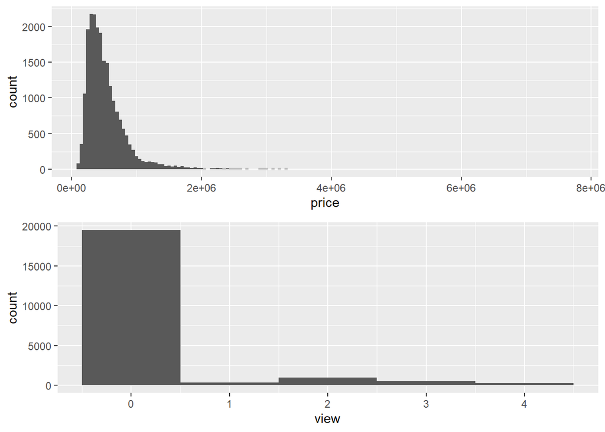

```r
grid.arrange(
#price distro
ggplot(house_data, mapping = aes(x = price)) +
 geom_histogram(binwidth = 50000),

# house with view distro
ggplot(house_data, mapping = aes(x = view)) +
  geom_histogram(binwidth = 1),

ncol = 1
)
```

You first store the plot objects:

```r
#price distro
p1 <- ggplot(house_data, mapping = aes(x = price)) +
 geom_histogram(binwidth = 50000)

# house with view distro
p2 <- ggplot(house_data, mapping = aes(x = view)) +
  geom_histogram(binwidth = 1)
```

- Note this does not display the plot
- Simply type the object name `p1` or `p2` in the console to display it

Instead of using grid.arrange(), we can now `+` or `|` to arrange plots horizontally, and `/` to arrange vertically:

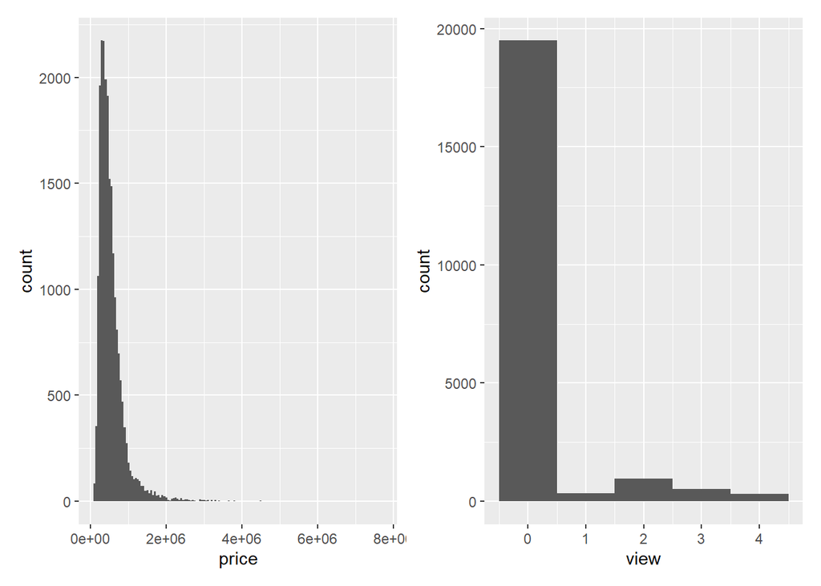

```r
p1 + p2
```

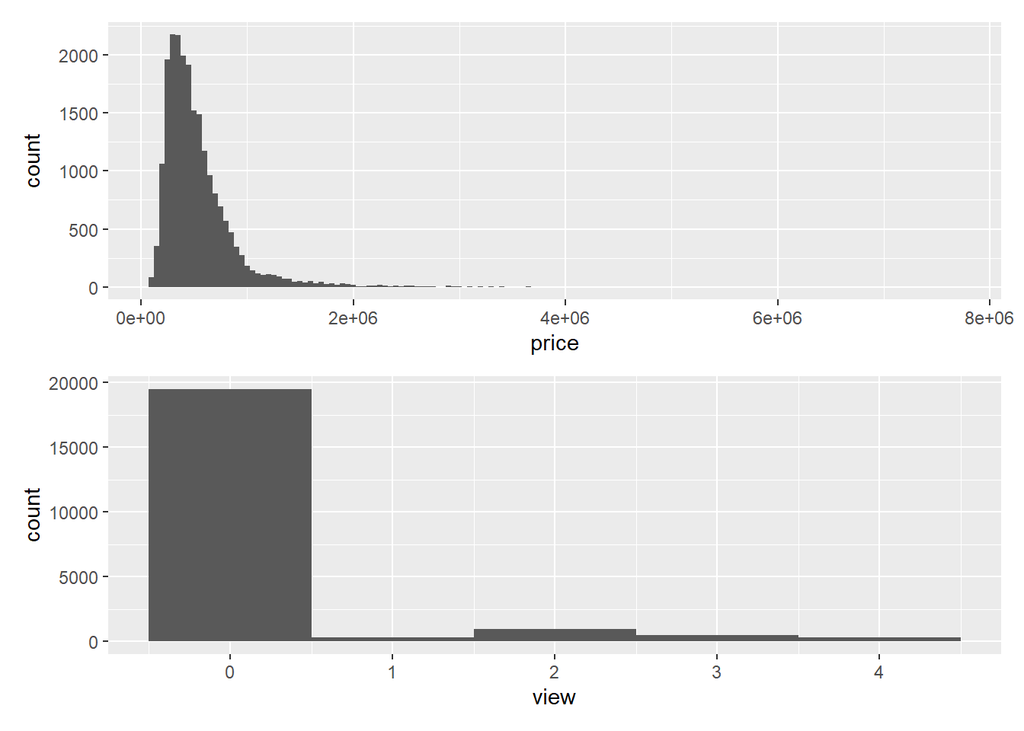

```r
p1 / p2
```

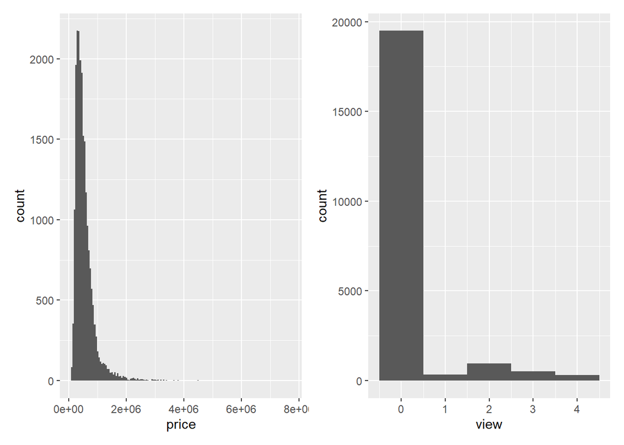

```r
p1 | p2
```

Let’s add a third plot and arrange a few different ways

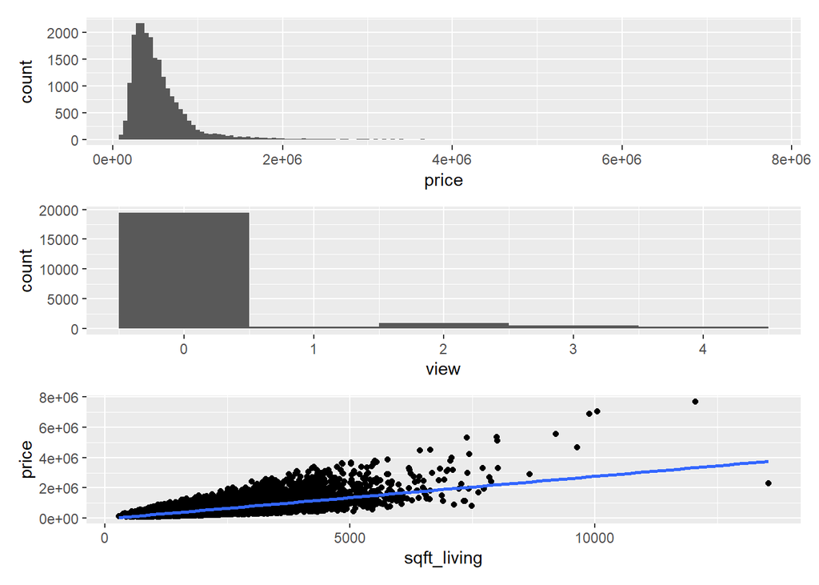

```r
p3 <- ggplot(house_data, mapping = aes(sqft_living, price)) +
  geom_point() +
  geom_smooth(method = 'lm')

p1 / p2 / p3
```

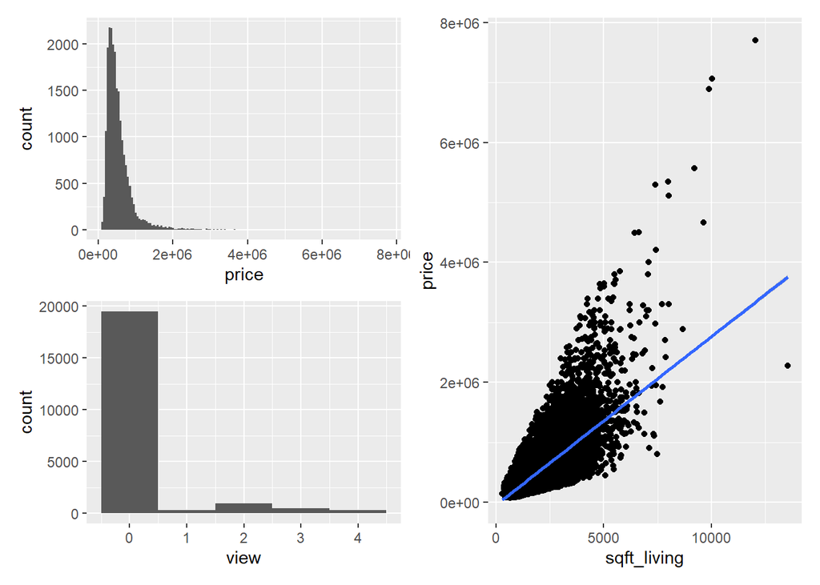

```r
(p1 / p2) | p3
```

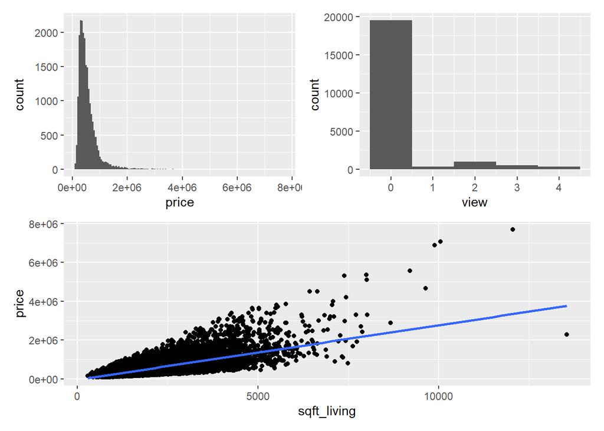

```r
(p1 | p2) / p3
```

A nice thing about storing plot objects is you can go back and add to them

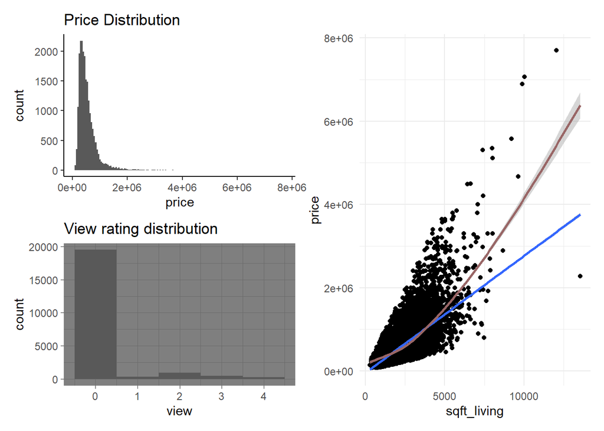

```r
p1 <- p1 + labs(title = 'Price Distribution') + theme_classic()

p2 <- p2 + labs(title = 'View rating distribution') + theme_dark()

p3 <- p3 + geom_smooth(method = 'loess', color = '#996666') + theme_minimal()

(p1 / p2) | p3
```

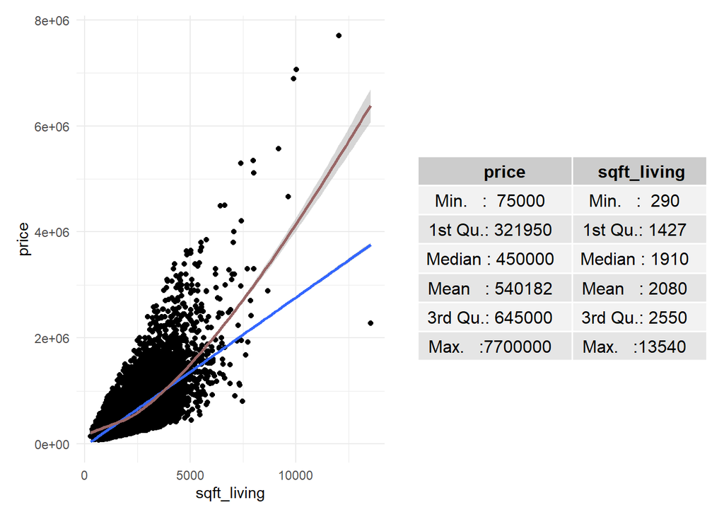

```r
p3 + tableGrob(summary(house_data[,c('price', 'sqft_living')]))
```

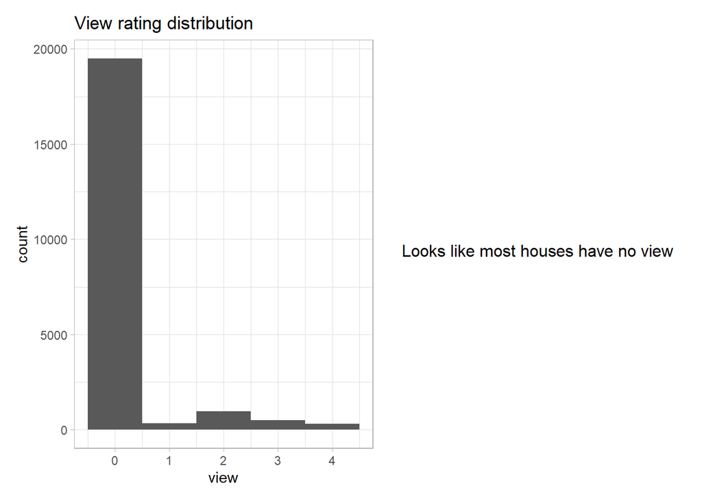

```r
p2 <- p2 + theme_light()
p2 + grid::textGrob('Looks like most houses have no view')
```

[For more advanced layouts and more tutorials visit this website](https://patchwork.data-imaginist.com/articles/guides/layout.html)